# Notebook

En este proyecto vamos a hacer un scraping web, es un método actualmente muy popular para extraer información de páginas web.

En este post estamos interesado en extraer la lista de licenciaturas que oferta la UCA para el 2019. Podemos observar la lista actualizada en [Carreras de Grado](http://www.uca.edu.ni/index.php/carreras). Pero en este post la lista es de la fecha de publicación.

[figure not shown]

Dejemos el palabrerío y ejecutemos:

-Importar los paquetes necesarios.

```python
import requests
from bs4 import BeautifulSoup
```

Si no conoces estos paquetes puedes preguntar al Señor Google por ellos. "requests, BeautifulSoup".

-Especificar la url a peinar.

```python
url = 'http://www.uca.edu.ni/index.php/carreras'
```

-Generar una variable llamada r que capture la validación de la url. Si es 200 indica que la página existe.

```python
r = requests.get(url)
print(r)
```

```
<Response [200]>
```

-Extraer la respuesta como html

```python
html_doc = r.text
```

-Embellecer con BeautifulSoup el html extraído.

```python
soup = BeautifulSoup(html_doc, 'lxml')
```

-Verificar si el título de la página es correcto

```python
print(soup.title)
```

```
<title>Carreras</title>
```

-Echemos un vistazo a lo que deberíamos extraer:

```python
print(soup)
```

[output not shown]

[output cut: 828 more lines]

[output not shown]

-Obteniendo el contenido como textos en una lista

```python
lista = []
for ul in soup.find_all('a'):
    texto = ul.get_text('href')
    lista.append(texto)
```

-En esta parte filtramos la información que queremos

```python
carreras = lista[54:73]
carreras
```

```
['Licenciatura en Derecho',
 'Licenciatura en Comunicación',
 'Licenciatura en Psicología',
 'Licenciatura en Trabajo Social y Gestión del Desarrollo',
 'Licenciatura en Enseñanza de Inglés como Lengua Extranjera',
 'Licenciatura en Sociología',
 'Licenciatura en Filosofía',
 'Arquitectura',
 'Ingeniería en Sistemas de Información',
 'Ingeniería en Redes y Telecomunicaciones',
 'Ingeniería Industrial',
 'Ingeniería Ambiental',
 'Ingeniería Civil',
 'Licenciatura en Diseño Gráfico',
 'Licenciatura en Administración de Empresas',
 'Licenciatura en Economía Aplicada',
 'Licenciatura en Contaduría Pública y Auditoría',
 'Licenciatura en Finanzas',
 'Licenciatura en Marketing']
```

-Veamos algunos métodos y funciones con la lista:

--Ordenando notamos que tienen Arquitectura, cinco ingenierías y trece licenciaturas

```python
carreras.sort()
carreras
```

```
['Arquitectura',
 'Ingeniería Ambiental',
 'Ingeniería Civil',
 'Ingeniería Industrial',
 'Ingeniería en Redes y Telecomunicaciones',
 'Ingeniería en Sistemas de Información',
 'Licenciatura en Administración de Empresas',
 'Licenciatura en Comunicación',
 'Licenciatura en Contaduría Pública y Auditoría',
 'Licenciatura en Derecho',
 'Licenciatura en Diseño Gráfico',
 'Licenciatura en Economía Aplicada',
 'Licenciatura en Enseñanza de Inglés como Lengua Extranjera',
 'Licenciatura en Filosofía',
 'Licenciatura en Finanzas',
 'Licenciatura en Marketing',
 'Licenciatura en Psicología',
 'Licenciatura en Sociología',
 'Licenciatura en Trabajo Social y Gestión del Desarrollo']
```

--El número de carreras que posee la UCA son 19.

```python
len(carreras)
```

```
19
```

--Tiene 13 licenciaturas

```python
import re
licenciaturas = re.findall('Licenciatura', str(carreras))
len(licenciaturas)
```

```
13
```

--Tiene 5 Ingenierías

```python
ingenierias = re.findall('Ingeniería', str(carreras))
len(ingenierias)
```

```
5
```

-- 1 es Arquitectura

--Observar la lista

```python
for i in carreras:
    print(i.capitalize())
```

```
Arquitectura
Ingeniería ambiental
Ingeniería civil
Ingeniería industrial
Ingeniería en redes y telecomunicaciones
Ingeniería en sistemas de información
Licenciatura en administración de empresas
Licenciatura en comunicación
Licenciatura en contaduría pública y auditoría
Licenciatura en derecho
Licenciatura en diseño gráfico
Licenciatura en economía aplicada
Licenciatura en enseñanza de inglés como lengua extranjera
Licenciatura en filosofía
Licenciatura en finanzas
Licenciatura en marketing
Licenciatura en psicología
Licenciatura en sociología
Licenciatura en trabajo social y gestión del desarrollo
```

--Grafiquemos en un gráfico de barras

```python
titulacion = ['Licenciatura', 'Ingeniería', 'Arquitectura']
cantidad = [len(licenciaturas), len(ingenierias), 1]
tabla = {'Titulacion':titulacion, 'Cantidad':cantidad}
import pandas as pd
tabla = pd.DataFrame(tabla)
tabla
```

|  | Titulacion | Cantidad |
| --- | --- | --- |
| 0 | Licenciatura | 13 |
| 1 | Ingeniería | 5 |
| 2 | Arquitectura | 1 |

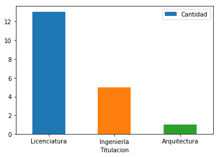

```python
import matplotlib.pyplot as plt
tabla.plot.bar(x='Titulacion', y='Cantidad', rot=0)
```